# Biostat M280 Homework 3

Due Mar 2 @ 11:59PM

Lumi Huang

## Q1 LA City Employee Payroll

Link to my shiny app: https://lumi-huang.shinyapps.io/hw3-shiny/

The `/home/m280-data/la_payroll/LA_City_Employee_Payroll.csv` file on teaching server contains payroll information of LA City employees in years 2013-2017. It was downloaded from [LA City Controller’s Office](https://controllerdata.lacity.org/Payroll/City-Employee-Payroll/pazn-qyym). Make a Shiny app to facilitate exploratory data analysis.

1. For efficiency of the Shiny app, you should first pre-process, pare down, tidy, and save the data, e.g., as a compressed RDS file, to be used in the app.
2. **Total payroll by LA City**. Visualize the total LA City payroll of each year, with breakdown into base pay, overtime pay, and other pay.
3. **Who earned most?** Visualize the payroll information (total payment with breakdown into base pay, overtime pay, and other pay, Department, Job Title) of the top $n$ highest paid LA City employees in a specific year. User specifies $n$ (default 10) and year (default 2017).
4. **Which departments earn most?** Visualize the mean or median payroll, with breakdown into base pay, overtime pay, and other pay, of top $n$ earning departments. User specifies $n$ (default 5), year (default 2017), and method (mean or median, default median).
5. **Which departments cost most?** Visualize the total payroll, with breakdown into base pay, overtime pay, and other pay, of top $n$ expensive departments. User specifies $n$ (default 5) and year (default 2017).
6. Visualize any other information you are interested in.
7. Publish your Shiny app to https://www.shinyapps.io and share the link.

## Q2 LA City Parking War

The SQLite database `/home/m280-data/la_parking/LA_Parking_Citations.sqlite` on teaching server contains information about parking tickets in LA City. It was downloaded from [LA Open Data Portal](https://data.lacity.org/A-Well-Run-City/Parking-Citations/wjz9-h9np). Connect to the database and answer following questions using plots and summary statistics. In this exercise, you are **not** allowed to load whole data into memory. Use the *transform in database, plot in R* strategy.

```r
library("DBI")
library("RSQLite")
library("tidyverse")
setwd(".")
db <- dbConnect(RSQLite::SQLite(), dbname =
                  "/home/m280-data/la_parking/LA_Parking_Citations_Extra.sqlite"
                )

dbListTables(db)
```

```
## [1] "latix"
```

```r
knitr::opts_chunk$set(connection = "db")

latix_sql <- dplyr::tbl(db, "latix")
str(latix_sql)
```

[output not shown]

```r
latix_sql %>% print(width = Inf)
```

```
## # Source:   table<latix> [?? x 23]
## # Database: sqlite 3.19.3
## #   [/home/m280-data/la_parking/LA_Parking_Citations_Extra.sqlite]
##    Ticket_number Issue_Year Issue_Month Issue_Day Issue_Hour Issue_Minute
##            <dbl>      <int>       <int>     <int>      <int>        <int>
##  1    4272349605       2015          12        30         22            1
##  2    4272349616       2015          12        30         22            5
##  3    4272821512       2015          12        30         17           25
##  4    4272821523       2015          12        30         17           38
##  5    4272821534       2015          12        30         18            7
##  6    4272889353       2015          12        30          5           14
##  7    4274301964       2016           1         4         12            5
##  8    1112509506       2015          12        21         12           55
##  9    1112509510       2015          12        21         13            5
## 10    1112509926       2015          12        21         13           40
```

[output cut: 37 more lines]

1. How many tickets are in this data set?

```r
latix_sql %>%
  count()
```

```
## # Source:   lazy query [?? x 1]
## # Database: sqlite 3.19.3
## #   [/home/m280-data/la_parking/LA_Parking_Citations_Extra.sqlite]
##         n
##     <int>
## 1 4044488
```

```sql
select count(*) from latix;
```

1 records

| count(*) |
| --- |
| 4044488 |

```r
time_period <- latix_sql %>%
  select(Issue_Year, Issue_Month, Issue_Day) %>%
  group_by(Issue_Year, Issue_Month, Issue_Day) %>%
  distinct() %>%
  arrange(Issue_Year, Issue_Month, Issue_Day)

time_period1 <- head(time_period)
time_period1
```

```
## # Source:     lazy query [?? x 3]
## # Database:   sqlite 3.19.3
## #   [/home/m280-data/la_parking/LA_Parking_Citations_Extra.sqlite]
## # Groups:     Issue_Year, Issue_Month, Issue_Day
## # Ordered by: Issue_Year, Issue_Month, Issue_Day
##   Issue_Year Issue_Month Issue_Day
##        <int>       <int>     <int>
## 1         NA          NA        NA
## 2       2010           4        27
## 3       2010           5         9
## 4       2010           5        21
## 5       2010           6         6
## 6       2010           6         9
```

```r
time_period2 <- latix_sql %>%
  select(Issue_Year, Issue_Month, Issue_Day) %>%
  group_by(Issue_Year, Issue_Month, Issue_Day) %>%
  distinct() %>%
  arrange(desc(Issue_Year), desc(Issue_Month), desc(Issue_Day))

time_period3 <- head(time_period2)
time_period3
```

```
## # Source:     lazy query [?? x 3]
## # Database:   sqlite 3.19.3
## #   [/home/m280-data/la_parking/LA_Parking_Citations_Extra.sqlite]
## # Groups:     Issue_Year, Issue_Month, Issue_Day
## # Ordered by: desc(Issue_Year), desc(Issue_Month), desc(Issue_Day)
##   Issue_Year Issue_Month Issue_Day
##        <int>       <int>     <int>
## 1       2017          12        30
## 2       2017          12        29
## 3       2017          12        28
## 4       2017          12        27
## 5       2017          12        26
## 6       2017          12        25
```

```sql
select min(Issue_Year), max(Issue_Year) from latix;
```

1 records

| min(Issue_Year) | max(Issue_Year) |
| --- | --- |
| 2010 | 2017 |

```sql
select min(Issue_Month) from latix
where Issue_Year = '2010';
```

1 records

| min(Issue_Month) |
| --- |
| 4 |

```sql
select min(Issue_Day) from latix
where Issue_Year = '2010' and Issue_Month = '4';
```

1 records

| min(Issue_Day) |
| --- |
| 27 |

```sql
select max(Issue_Month) from latix
where Issue_Year = '2017';
```

1 records

| max(Issue_Month) |
| --- |
| 12 |

```sql
select max(Issue_Day) from latix
where Issue_Year = '2017' and Issue_Month = '12';
```

1 records

| max(Issue_Day) |
| --- |
| 30 |

tickets span from 2010/04/27 to 2017/12/30

Which years have most data?

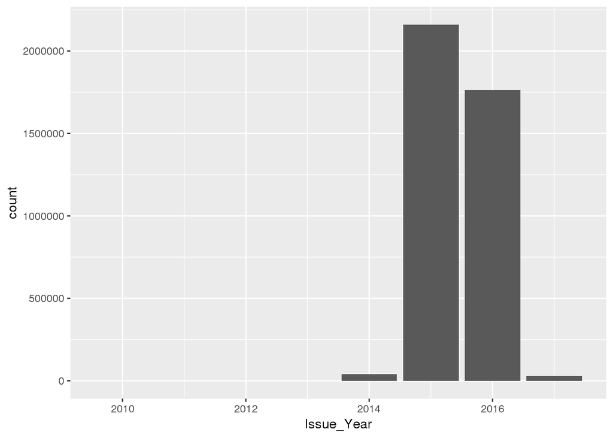

```r
latix_sql %>%
  select(Issue_Year) %>%
  group_by(Issue_Year) %>%
  filter(!is.na(Issue_Year)) %>%
  collect() %>%
  ggplot(mapping = aes(x = Issue_Year)) +
  geom_bar()
```

```sql
select Issue_Year, count(*) from latix
group by Issue_Year
order by count(*) desc;
```

9 records

| Issue_Year | count(*) |
| --- | --- |
| 2015 | 2161119 |
| 2016 | 1763273 |
| NA | 51084 |
| 2014 | 39206 |
| 2017 | 29719 |
| 2013 | 38 |
| 2012 | 29 |
| 2010 | 10 |
| 2011 | 10 |

2015 has most data

0. When (which hour, weekday, month day, and month) are you most likely to get a ticket and when are you least likely to get a ticket?

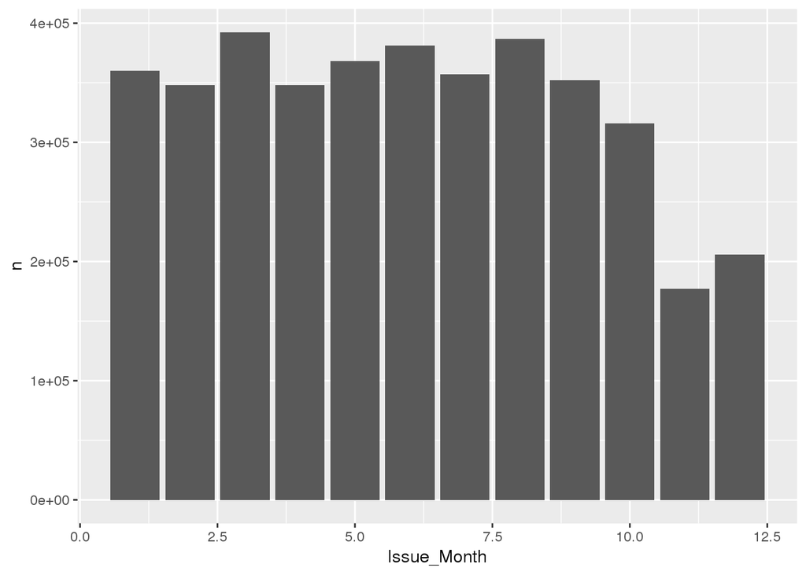

```r
#month
latix_sql %>%
  select(Issue_Month) %>%
  group_by(Issue_Month) %>%
  count() %>%
  collect() %>%
  ggplot(mapping = aes(x = Issue_Month, y = n)) +
  geom_col()
```

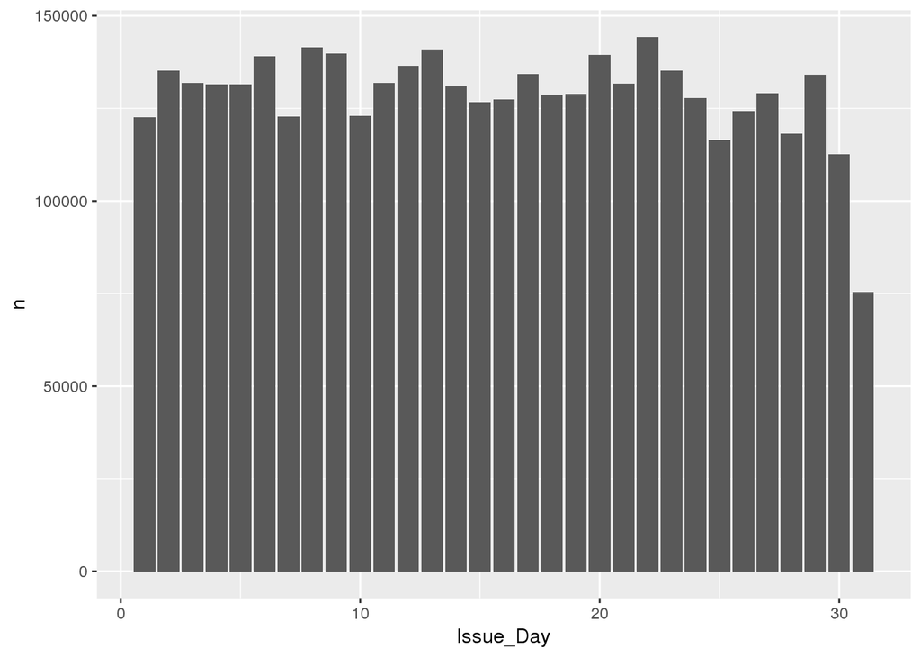

```r
#day
latix_sql %>%
  select(Issue_Day) %>%
  group_by(Issue_Day) %>%
  count() %>%
  collect() %>%
  ggplot(mapping = aes(x = Issue_Day, y = n)) +
  geom_col()
```

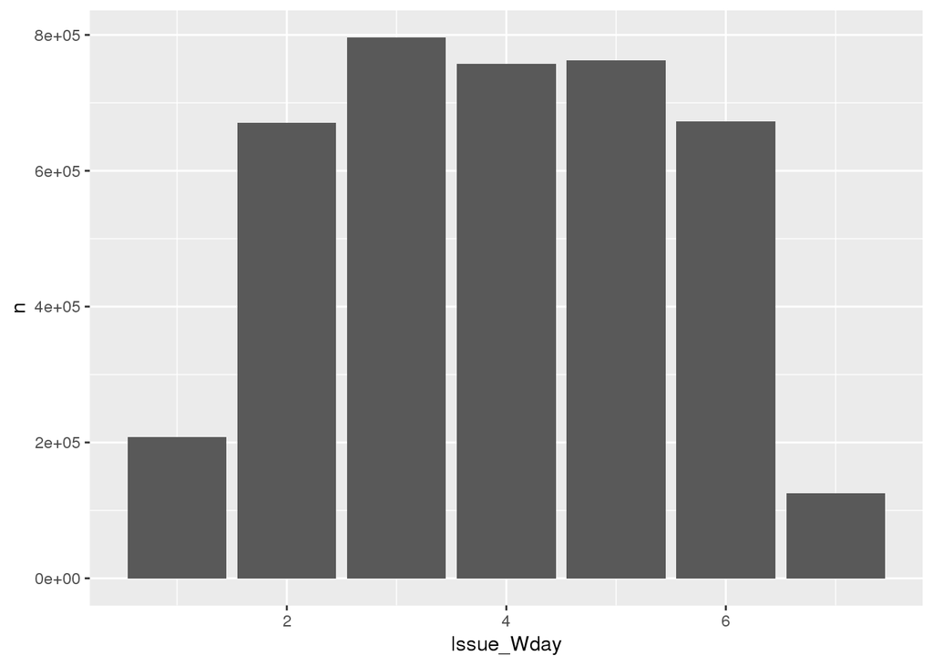

```r
#Weekday
latix_sql %>%
  select(Issue_Wday) %>%
  group_by(Issue_Wday) %>%
  count() %>%
  collect() %>%
  ggplot(mapping = aes(x = Issue_Wday, y = n)) +
  geom_col()
```

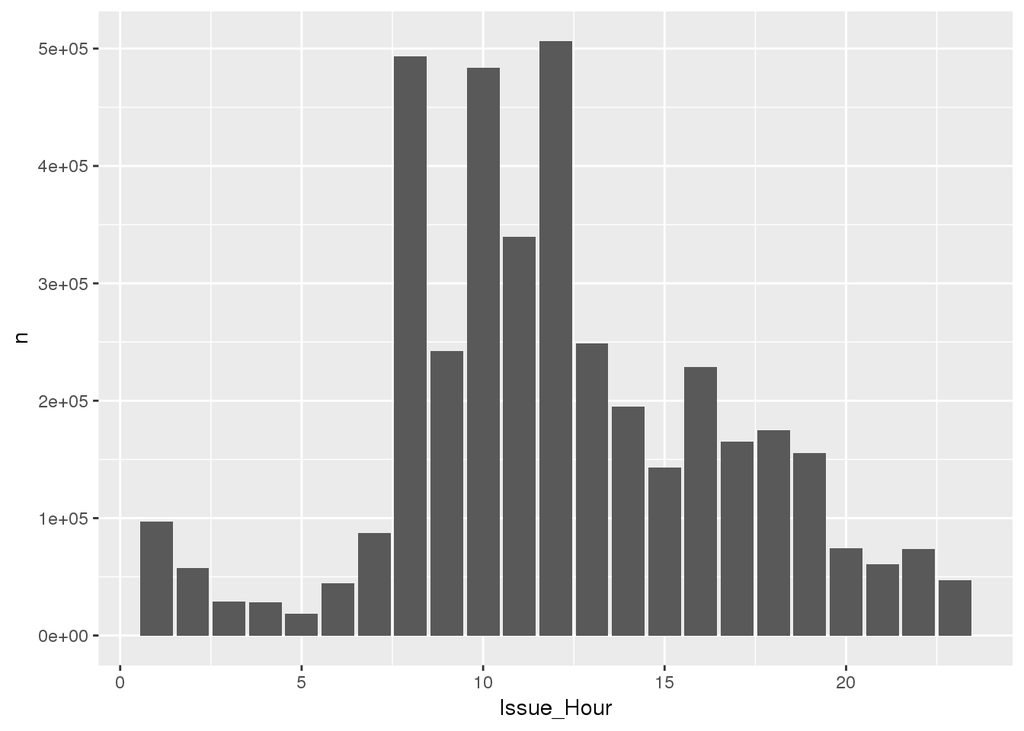

```r
#Hour
latix_sql %>%
  select(Issue_Hour) %>%
  group_by(Issue_Hour) %>%
  count() %>%
  collect() %>%
  ggplot(mapping = aes(x = Issue_Hour, y = n)) +
  geom_col()
```

Most Likely: Month: 3 Day: 22 Weekday: Wed Hour: 12pm

Least Likely: Month: 11 Day: 31 Weekday: Sun Hour: 5am

0. Which car makes received most citations?

```r
car_make <- latix_sql %>%
  select(Make) %>%
  group_by(Make) %>%
  count() %>%
  arrange(desc(n)) %>%
  collect()
car_make_h <- head(car_make)

car_make_h
```

```
## # A tibble: 6 x 2
## # Groups:   Make [6]
##   Make       n
##   <chr>  <int>
## 1 TOYT  669548
## 2 HOND  450020
## 3 FORD  362072
## 4 NISS  277215
## 5 CHEV  276530
## 6 BMW   184837
```

```sql
select make, count(*) from latix
group by make
order by count(*) desc
limit 5;
```

5 records

| Make | count(*) |
| --- | --- |
| TOYT | 669548 |
| HOND | 450020 |
| FORD | 362072 |
| NISS | 277215 |
| CHEV | 276530 |

Toyota

0. How many different colors of cars were ticketed? Which color attracted most tickets?

```r
latix_sql %>%
  select(Color) %>%
  distinct() %>%
  count() %>%
  collect()
```

```
## # A tibble: 1 x 1
##       n
##   <int>
## 1    66
```

```r
CAMT <- latix_sql %>%
  select(Color) %>%
  group_by(Color) %>%
  count() %>%
  arrange(desc(n)) %>%
  collect()
head(CAMT)
```

```
## # A tibble: 6 x 2
## # Groups:   Color [6]
##   Color      n
##   <chr>  <int>
## 1 BK    862283
## 2 WT    818655
## 3 GY    765598
## 4 SL    516384
## 5 BL    317921
## 6 RD    205304
```

There are 66 different colors of cars were ticketed, and color Black attracted most tickets.

0. What are the most common ticket types?

```r
MCT <- latix_sql %>%
  select(Violation_Description) %>%
  group_by(Violation_Description) %>%
  count() %>%
  arrange(desc(n))
head(MCT)
```

```
## # Source:     lazy query [?? x 2]
## # Database:   sqlite 3.19.3
## #   [/home/m280-data/la_parking/LA_Parking_Citations_Extra.sqlite]
## # Groups:     Violation_Description
## # Ordered by: desc(n)
##   Violation_Description       n
##   <chr>                   <int>
## 1 NO PARK/STREET CLEAN  1149021
## 2 METER EXP.             773228
## 3 PREFERENTIAL PARKING   281060
## 4 RED ZONE               274880
## 5 DISPLAY OF TABS        243638
## 6 NO PARKING             182747
```

NO PARK/STREET CLEAN is the most common ticket types.

0. How much money was collected on parking tickets in 2015 and 2016?

```r
latix_sql %>%
  select(Issue_Year, Fine_amount) %>%
  filter(Issue_Year == "2015" | Issue_Year == "2016") %>%
  group_by(Issue_Year) %>%
  summarise(Total_Fine = sum(Fine_amount, na.rm = TRUE)) %>%
  arrange(desc(Total_Fine))
```

```
## # Source:     lazy query [?? x 2]
## # Database:   sqlite 3.19.3
## #   [/home/m280-data/la_parking/LA_Parking_Citations_Extra.sqlite]
## # Ordered by: desc(Total_Fine)
##   Issue_Year Total_Fine
##        <int>      <int>
## 1       2015  151006794
## 2       2016  123236136
```

In 2015, 151006794 usd was collected. In 2016, 123236136 usd was collected.

0. Visualize any other information you are interested in. Which location collect the most money in 2015

```r
Location <- latix_sql %>%
  select(Issue_Year, Location, Fine_amount) %>%
  filter(Issue_Year == "2015") %>%
  group_by(Location) %>%
  summarise(Total_Fine = sum(Fine_amount, na.rm = TRUE)) %>%
  arrange(desc(Total_Fine))
head(Location)
```

```
## # Source:     lazy query [?? x 2]
## # Database:   sqlite 3.19.3
## #   [/home/m280-data/la_parking/LA_Parking_Citations_Extra.sqlite]
## # Ordered by: desc(Total_Fine)
##   Location             Total_Fine
##   <chr>                     <int>
## 1 11600 SAN VICENTE BL     154224
## 2 1235 FIGUEROA PL         140734
## 3 101 LARCHMONT BL N       120476
## 4 6041 CADILLAC AVE        107483
## 5 4867 SUNSET BLVD W       102646
## 6 12100 VENTURA BL          93902
```

11600 SAN VICENTE BL collected the most money in 2015